# manuscript

Maria Klitgaard Christensen

18 march 2019

## Introduction

In this experiment we collected some data and all went **extremely** well.

Explaining what *this* document is about - what is going on. Maybe even before I start analysing data.

If I want something squared(super script): kg/m<sup>2</sup>

If I want something subscript: H<sub>2</sub>O

If I want to do bullet points

- item **1**
- item 2
- item 3
- item 4 There must be a line break before and after a new sentence or bullet list, otherwise R think that it is a part of the previous paragraph.

If I want to see a draft of my R Markdown in the global environment, I go into Tools -> Global Options –> R Markdown –> Viewer plane. If I instead want to have a pop up window I change the Viewer Plane to ‘Window’.

1. first step
2. second step

To make a ‘block quote’ (if I want to make something pop out, but the teachers very rarely use it)

To make a footnote I have to do the following:

This is a footnote[^1] This will be footnote number 2 yeah[^2] It is a bit annoying that you have to keep track of the footnote number[^3] yourself.

Write your footnotes in the end of each section. Then it is easier to keep travk of the footnotes and they will still be in the end of the document.

## Methods

This is the amazing methods we used.

[figure not shown]

The two dots before the pathway and picture name means that R Markdown has to go two ‘folders’ up and look for the picture. Since this is R Markdown I cannot use ‘here::here’ as when I am writing a script. Indstead use dots.

This is an example of a link

[This is the source to amazing information](http://www.google.com)

The principle for inserting a image and inserting a link is the same, but there is just not a ‘!’ for interting links but there are for pictures.

Normally, you should use a function called table to insert a table. You do not write everthyng by hand, but it is possible.

|  | Fun | Source |
| --- | --- | --- |
| **Happy** | 1234 | 5678 |
| **Sad** | 5648 | 9852 |

Now I want to include some means of the experiment. To do this, click ‘insert (green bottom) and choose ’R’ and then I get the block of R code:

```
##   Sepal.Length    Sepal.Width     Petal.Length    Petal.Width
##  Min.   :4.300   Min.   :2.000   Min.   :1.000   Min.   :0.100
##  1st Qu.:5.100   1st Qu.:2.800   1st Qu.:1.600   1st Qu.:0.300
##  Median :5.800   Median :3.000   Median :4.350   Median :1.300
##  Mean   :5.843   Mean   :3.057   Mean   :3.758   Mean   :1.199
##  3rd Qu.:6.400   3rd Qu.:3.300   3rd Qu.:5.100   3rd Qu.:1.800
##  Max.   :7.900   Max.   :4.400   Max.   :6.900   Max.   :2.500
##        Species
##  setosa    :50
##  versicolor:50
##  virginica :50
##
##
##
```

```
##       mpg             cyl             disp             hp
##  Min.   :10.40   Min.   :4.000   Min.   : 71.1   Min.   : 52.0
##  1st Qu.:15.43   1st Qu.:4.000   1st Qu.:120.8   1st Qu.: 96.5
##  Median :19.20   Median :6.000   Median :196.3   Median :123.0
##  Mean   :20.09   Mean   :6.188   Mean   :230.7   Mean   :146.7
##  3rd Qu.:22.80   3rd Qu.:8.000   3rd Qu.:326.0   3rd Qu.:180.0
##  Max.   :33.90   Max.   :8.000   Max.   :472.0   Max.   :335.0
##       drat             wt             qsec             vs
##  Min.   :2.760   Min.   :1.513   Min.   :14.50   Min.   :0.0000
##  1st Qu.:3.080   1st Qu.:2.581   1st Qu.:16.89   1st Qu.:0.0000
##  Median :3.695   Median :3.325   Median :17.71   Median :0.0000
##  Mean   :3.597   Mean   :3.217   Mean   :17.85   Mean   :0.4375
##  3rd Qu.:3.920   3rd Qu.:3.610   3rd Qu.:18.90   3rd Qu.:1.0000
##  Max.   :4.930   Max.   :5.424   Max.   :22.90   Max.   :1.0000
##        am              gear            carb
##  Min.   :0.0000   Min.   :3.000   Min.   :1.000
##  1st Qu.:0.0000   1st Qu.:3.000   1st Qu.:2.000
##  Median :0.0000   Median :4.000   Median :2.000
##  Mean   :0.4062   Mean   :3.688   Mean   :2.812
##  3rd Qu.:1.0000   3rd Qu.:4.000   3rd Qu.:4.000
##  Max.   :1.0000   Max.   :5.000   Max.   :8.000
```

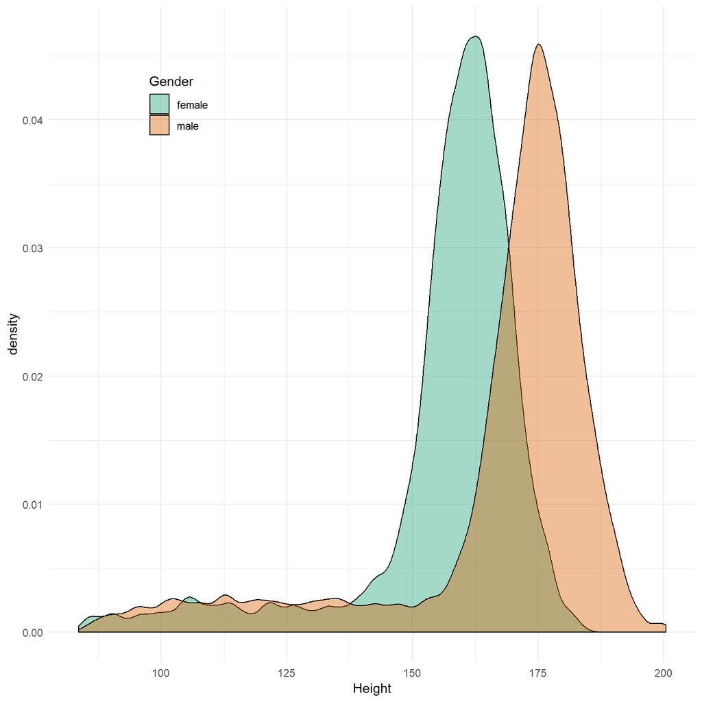

| Diabetes | 2009_10 | 2011_12 |
| --- | --- | --- |
| No | 26.37582 | 25.94804 |
| Yes | 32.58843 | 32.53279 |
| NA | 40.76000 | 22.20000 |

# Standard R Markdown text

```
##      speed           dist
##  Min.   : 4.0   Min.   :  2.00
##  1st Qu.:12.0   1st Qu.: 26.00
##  Median :15.0   Median : 36.00
##  Mean   :15.4   Mean   : 42.98
##  3rd Qu.:19.0   3rd Qu.: 56.00
##  Max.   :25.0   Max.   :120.00
```

[^1]: This is the text of footnote number 1
[^2]: This is the second footnote
[^3]: This is the third footnote